# Vos requêtes SQL 10 000x plus rapide, durablement

### Index B-Tree

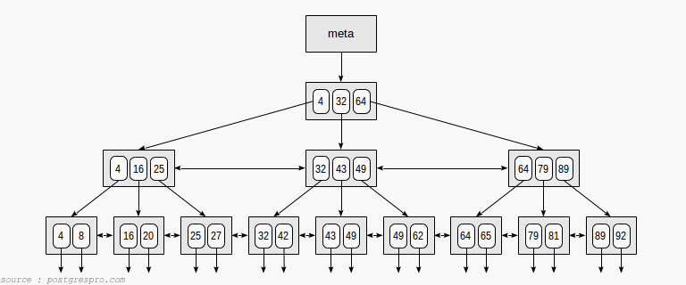

- Indexation des valeurs
- Arbre balancé, classique, efficace ✅
- Volumétrie et fragmentation ⚠️
- Probablement 100 % de vos index aujourd’hui 💯

### Index BRIN

```sql
CREATE INDEX idx_log_ts_btree ON log(ts);
CREATE INDEX idx_log_ts_brin ON log USING brin (ts);

postgres=# \di+
       Nom        | Type  | Table | Méthode d'accès | Taille
------------------+-------+-------+-----------------+----------
 idx_log_ts_brin  | index | log   | brin            | 24 kB
 idx_log_ts_btree | index | log   | btree           | 21 MB
```

- Mon index préféré 👆
- Indexation de plages de données
- Idéal pour les grosses volumétries ordonnées

### Index Génériques (GIN/GiST)

```sql
CREATE INDEX ON stock_jsonb USING gin (document_jsonb);
CREATE INDEX ON mes_points USING gist (p);
```

- **GIN** efficace mais coûteux à maintenir
- **GiST** plus léger, peut être suffisant
- Données non structurées (`JSON`, `TEXT`…)
- Full text search avec `pg_trgm`
- Données spatiales avec `PostgGIS`

### Statistiques

- **supervision**
- **planification**
- processus `autovacuum`
- `ANALYZE`

### Statistiques de supervision

- 43 vues à votre disposition (v17)
  - `pg_stat_activity`,
  - `pg_stat_user_tables`,
  - `pg_stat_io`,
  - …
- Extension `pg_stat_statements`
- Sonde [`check_pgactivity`](https://github.com/OPMDG/check_pgactivity)
- Console de supervision [PoWA](https://github.com/powa-team/powa)
- Console d’administration [temBoard](https://github.com/dalibo/temboard)

### PoWA

[figure not shown]

### Statistiques de planification

```sql
postgres=# \d pg_stats
 ...
 schemaname          | name
 tablename           | name
 attname             | name     -- nom de la colonne
 null_frac           | real     -- % de valeurs nulles
 avg_width           | integer  -- taille moyenne des valeurs en octets
 n_distinct          | real     -- nombre de valeurs distinctes
 most_common_vals    | anyarray -- valeurs les plus fréquentes
 most_common_freqs   | real[]   -- fréquences des valeurs fréquentes
 histogram_bounds    | anyarray -- histogramme
 correlation         | real     -- ordre physique des données => BRIN
 ...
```

### Statistiques multivariées

```sql
CREATE STATISTICS stat_dpt ON code_postal, departement FROM adresse ;
```

- pour les dépendances fonctionnelles
- dali.bo/perf1_html

## Big Data ? NoSQL ?

- **PostgreSQL** tient le coup sur des bases de **dizaines de To**
  - pour peu que le matériel suive…
- Partitionnement parfois utile
  - pour faciliter la maintenance
  - pour faciliter l’administration
- Stockage colonne avec `citus_columnar`
- pgvector, TimescaleDB, CitusData…

## Vis ma vie

- Une histoire de requête lente
- Une histoire de micro-services

### Une histoire de requête lente

### Une histoire de requête lente

```sql
EXPLAIN ANALYZE SELECT column_a, created_at
FROM table_a
WHERE
 external_id = (SELECT id FROM table_b WHERE unique_key = '_UNiquEv4L_')
 AND LOWER(column_b) = 'a2bc-34de-45f0'
 AND some_id = -1234
 AND other_id = (SELECT id FROM table_c WHERE some_id = table_a.some_id)
ORDER BY created_at DESC
LIMIT 1
```

```
Limit  (cost=1570746.37..1570746.38 rows=1 width=671)
       (actual time=240016.770..240016.781 rows=1 loops=1)
   ->  Sort  (cost=1570746.37..1570746.39 rows=10 width=671)
             (actual time=240016.767..240016.776 rows=1 loops=1)
         Sort Key: table_a.created_at DESC
         Sort Method: top-N heapsort  Memory: 25kB
         InitPlan 1 (returns $0)
           ->  Index Scan using unique_key_constraint on table_b
           (cost=0.27..8.29 rows=1 width=4)
           (actual time=0.567..0.575 rows=1 loops=1)
                 Index Cond: ((unique_key)::text = '_UNiquEv41ue_'::text)
         ->  Bitmap Heap Scan on table_a  (cost=33130.70..1570737.91 rows=10 width=671)
                ...
Planning time: 18.432 ms
Execution time: 240021.889 ms
```

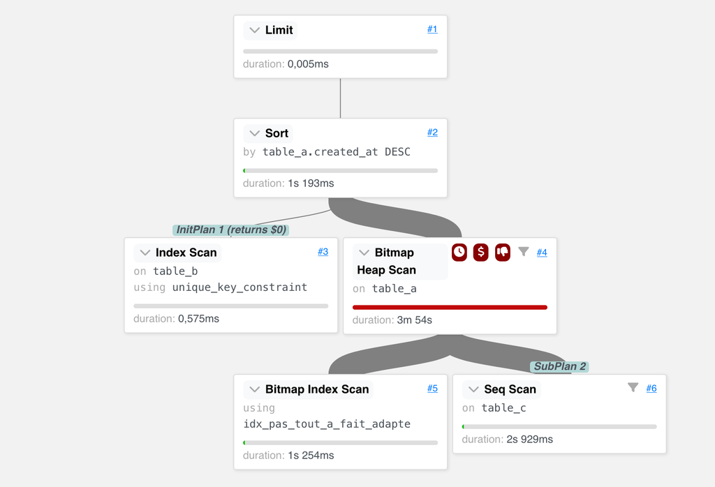

### Une histoire de requête lente

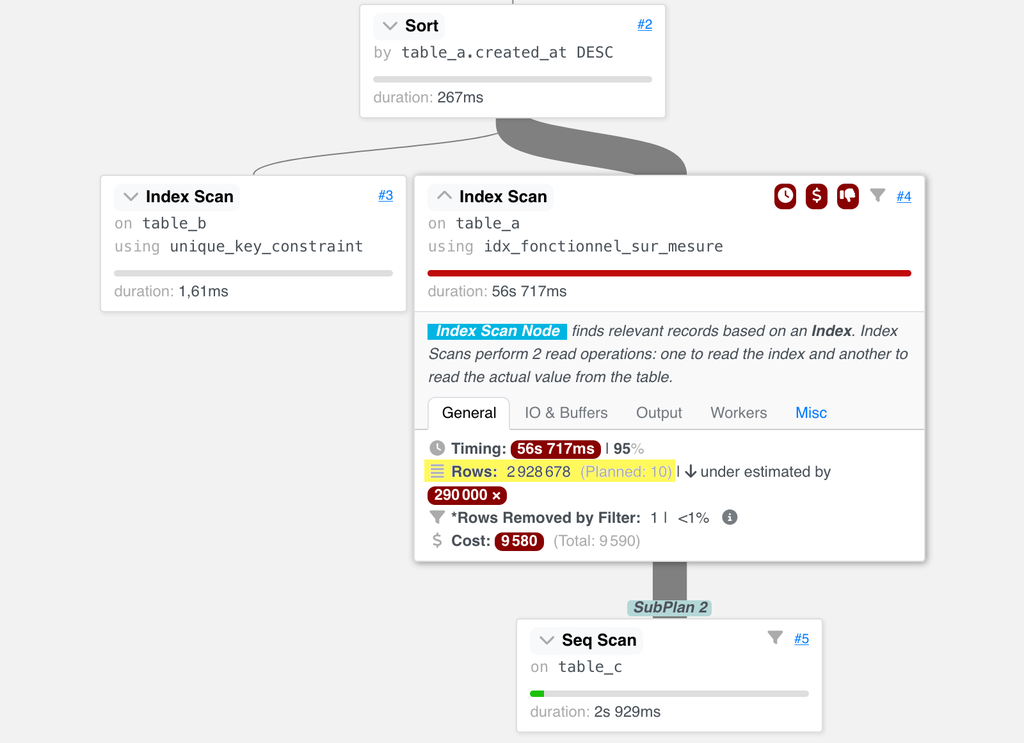

```sql
CREATE INDEX idx_fonctionnel_sur_mesure
ON table_a(external_id, LOWER(column_b), some_id);
```

### Une histoire de requête lente

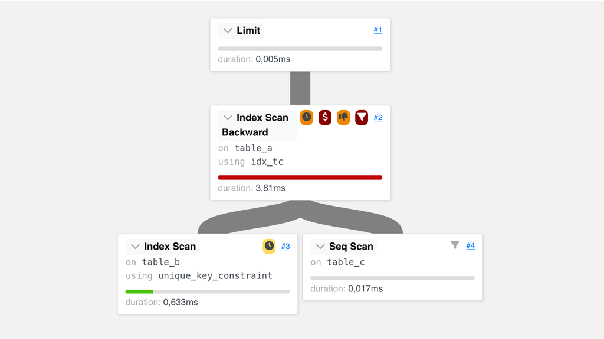

```sql
ANALYZE table_a;
```

### Une histoire de micro-services

### Une histoire de micro-services

- **Principe**
  - Isolation des fonctionnalités
  - Conteneurisation & Orchestration
  - *multitenant* PostgreSQL

### Une histoire de micro-services

[figure not shown]

### Une histoire de micro-services

- **Problème**
  - Cohérence des données entre services
  - Jointures entre services *(Foreign Data Wrapper)*

### Une histoire de micro-services

[figure not shown]

### Une histoire de micro-services

- **Solution**
  - un **schéma** par service
  - séparation logique conservée
  - **garantie ACID globale**
  - jointures possibles nativement
  - toujours sur une seule instance

### Une histoire bonus …

### les ORM ❤️

### Une histoire bonus : les ORM

- **Problèmes**
  - toutes les colonnes systématiquement sélectionnées
  - requêtes avec des dizaines de jointures

### Une histoire bonus : les ORM

- **Solution**

```sql
  ALTER SYSTEM SET `join_collapse_limit` = 12 ; -- 8 par
  ALTER SYSTEM SET `from_collapse_limit` = 12 ; -- défaut
```

## À retenir

- PostgreSQL est **un outil efficace** (et libre !)
  - + de 50 ans de recherche
  - + de 30 ans de développement
- Votre PGaaS ne connaît
  - ni votre métier
  - ni votre application
- **Une décision = 10 ans**

### Liens utiles

- La documentation postgresql.org/docs/
- Le code source doxygen.postgresql.org/
- Le git PostgreSQL git.postgresql.org/gitweb/
- Les listes mail postgresql.org/list/
- **La KB DALIBO** ! dali.bo/kb

## DALIBO : 20 ans de contribution ! 🎂🎉

dali.bo/labs

[figure not shown]

- et PostgreSQL 18 !
  - amélioration autovacuum [*(commit)*](https://git.postgresql.org/gitweb/?p=postgresql.git;a=commit;h=306dc520b9dfd6014613961962a89940a431a069)
  - supervision de la parallélisation [*(commit)*](https://git.postgresql.org/gitweb/?p=postgresql.git;a=commit;h=de3a2ea3b264a5625cda6d8968f75e9bfb4dbdcb)

## Merci !

*des questions ?*

[figure not shown]

LinkedIN : [@lesagealain](https://linkedin.com/in/lesagealain)